# Group project

Bayesian Multilevel Models

Yasemin Ozturk

Wafa Mohamed

Mladen Mladenov

2023-05-29

# Checklist

The submission includes the following.

- RMD/R document where it’s clear what is the code that corresponds to each question.
- Dataset
- html/PDF document with the following
  - Numbered questions and answers with text and all the necessary code.
  - Cover with group number and name of all group members
  - Details of specification of the work done by group members (e.g., who found the data, who did the pre-processing, who answered which questions, etc).

# Group project

For the project, we use the following packages:

```r
library(dplyr)
library(brms)
library(ggplot2)
library(tidyr)
library(glue)
library(ggrepel)
library(priorsense)
library(styler)
library(brms)
library(readr)
```

## 1. Dataset Selection (1pt)

Select a dataset with clusters such as schools, regions, or people with multiple observations per individual. (From for example, https://www.kaggle.com/) It would be a good idea to choose a smallish dataset (not too many rows, e.g., less than 1000) or subset it so that fitting the models doesn’t take too long.

1. Describe the dataset with a couple of short sentences. What was its intended use? Are there papers that reference it? Provide information on how to obtain the dataset, including its source and any necessary preprocessing steps/feature engineering.

> The dataset is downloaded from Kaggle [1]. It represents the average price per unit of Hass avocados (also per bag sold) and is intended to give an overview of how many avocados were sold in retailstores around the USA. It was inspired by the question whether there was a real ‘avocadopocalype’ in 2017, meaning an extreme rise in demand for avocados. The dataset can be used to look at differeces in price for different years and regions. It seems that there are no reference papers using this dataset, but in Kaggle it is used quite a lot for different purposes.

> To use this data for fitting the models, we scaled all the variables in the dataset except the ‘Average.Price’ (target) and ‘City’ (clusters) columns. This is done so we don’t have to define all the priors of each variables individually.

```r
avocado <- read.csv("avocado.csv")

avocado <- avocado %>%
  filter(year == 2018 & !region %in% c("California", "GreatLakes", "Midsouth", "NewOrleansMobile", "Northeast", "NorthernNewEngland", "PhoenixTucson", "Plains", "RaleighGreensboro", "RichmondNorfolk", "Roanoke", "SouthCarolina", "SouthCentral", "Southeast", "TotalUS", "West", "WestTexNewMexico")) %>%
  select(!c(X, Date, year, Total.Bags, Total.Volume)) %>%
  rename(c("Small.Medium.Bulk" = X4046, "Large.Bulk" = X4225, "XLarge.Bulk" = X4770, "City" = region, "Type" = type, "Average.Price" = AveragePrice)) %>%
  mutate(Type = ifelse(Type == "conventional", 0, 1))

s_avocado <- avocado %>%
  select(!c(Average.Price, City)) %>%
  scale() %>%
  bind_cols(select(avocado, Average.Price, City))
```

2. Report its number of observations, columns (with their meaning) and their data types.

```r
ncol(avocado)
```

```
[1] 9
```

```r
nrow(avocado)
```

```
[1] 888
```

```r
str(avocado)
```

```
'data.frame':   888 obs. of  9 variables:
 $ Average.Price    : num  1.57 1.35 1.12 1.08 1.28 1.43 1.45 1.03 1.57 1.69 ...
 $ Small.Medium.Bulk: num  16362 13235 15823 12002 10369 ...
 $ Large.Bulk       : num  109045 61038 110951 105070 59723 ...
 $ XLarge.Bulk      : num  65.5 55 70 95.6 48 ...
 $ Small.Bags       : num  19274 26756 14481 16129 30126 ...
 $ Large.Bags       : num  4271 3721 3033 5941 3702 ...
 $ XLarge.Bags      : num  380 500 291 283 310 ...
 $ Type             : num  0 0 0 0 0 0 0 0 0 0 ...
 $ City             : chr  "Albany" "Albany" "Albany" "Albany" ...
```

## 2. Research Question (0.5pt)

Formulate a research question that involves predicting a specific outcome variable based on the available dataset.

> Research Goal: Global demand for avocados has skyrocketed in recent years [2]. Part of this has been driven by a demand for a healthier lifestyle. However, this rise in demand also means an increase in prices. In order for households to be better prepared for the market and still be able to obtain their green goods, we are building a predictive model that checks what would the average price of an avocado be based on historical data.

> Research Question: Which model best predicts the average price of avocados in different US cities?

## 3. Model Exploration (3pt)

1. Fit multiple appropriate models to the dataset (as many models as there are members in the group, with a minimum of two models). Models might vary in the multilevel structure, informativeness of their priors (but not just trivial changes), model of the data/likelihood, etc. (I recommend not to use no pooling models since they tend to take a long time and it’s very hard to assign good priors).

```r
# Model 1: ignoring that there are different cities
priors_model1 <- c(
  prior_string(glue("normal({mean(s_avocado$Average.Price)}, {2.5 * sd(s_avocado$Average.Price)})"), class = "Intercept"),
  prior_string(glue("normal(0, {2.5 * sd(s_avocado$Average.Price)})"),
    class = "b"
  ),
  prior_string(glue("exponential({ 1/sd(s_avocado$Average.Price)})"),
    class = "sigma"
  )
)

model_1 <- brm(Average.Price ~ Small.Medium.Bulk + Large.Bulk + XLarge.Bulk + Small.Bags + Large.Bags + XLarge.Bags + Type,
  data = s_avocado,
  seed = 123,
  prior = priors_model1
)
```

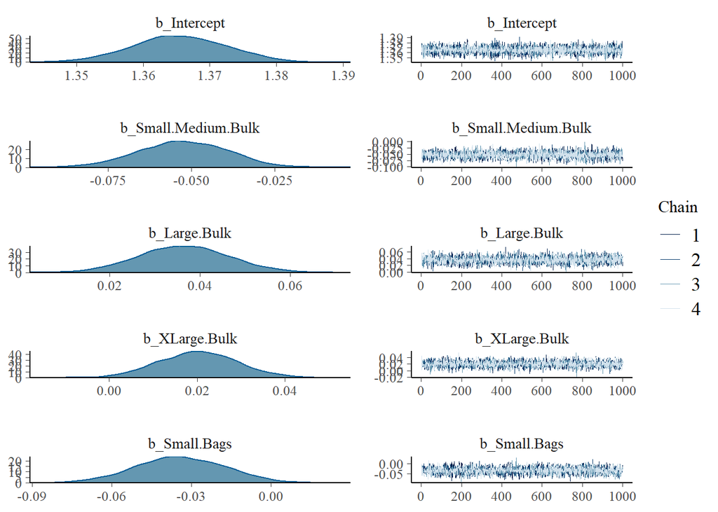

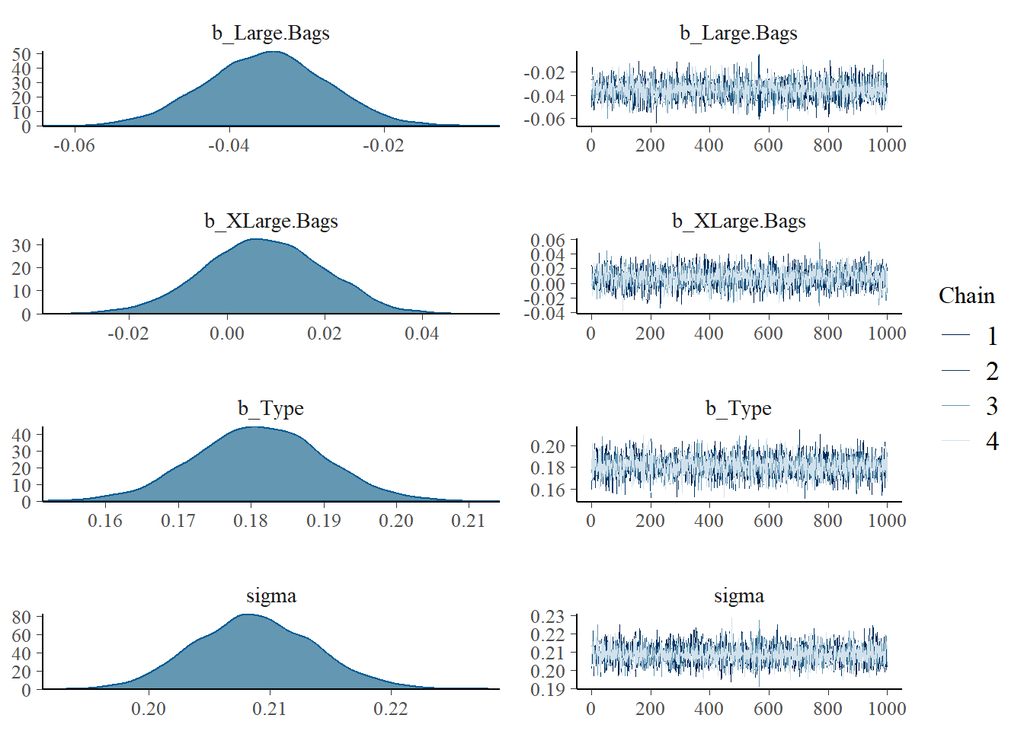

```r
plot(model_1)
```

```r
model_1
```

```
 Family: gaussian
  Links: mu = identity; sigma = identity
Formula: Average.Price ~ Small.Medium.Bulk + Large.Bulk + XLarge.Bulk + Small.Bags + Large.Bags + XLarge.Bags + Type
   Data: s_avocado (Number of observations: 888)
  Draws: 4 chains, each with iter = 2000; warmup = 1000; thin = 1;
         total post-warmup draws = 4000

Population-Level Effects:
                  Estimate Est.Error l-95% CI u-95% CI Rhat Bulk_ESS Tail_ESS
Intercept             1.37      0.01     1.35     1.38 1.00     6648     2310
Small.Medium.Bulk    -0.05      0.01    -0.08    -0.03 1.00     4233     2802
Large.Bulk            0.04      0.01     0.02     0.06 1.00     3943     3177
XLarge.Bulk           0.02      0.01     0.00     0.04 1.00     4260     3186
Small.Bags           -0.03      0.02    -0.07    -0.00 1.00     3218     3064
Large.Bags           -0.04      0.01    -0.05    -0.02 1.00     5132     3226
XLarge.Bags           0.01      0.01    -0.02     0.03 1.00     3618     3090
Type                  0.18      0.01     0.16     0.20 1.00     5214     3000

Family Specific Parameters:
      Estimate Est.Error l-95% CI u-95% CI Rhat Bulk_ESS Tail_ESS
sigma     0.21      0.00     0.20     0.22 1.00     5647     2916

Draws were sampled using sampling(NUTS). For each parameter, Bulk_ESS
and Tail_ESS are effective sample size measures, and Rhat is the potential
scale reduction factor on split chains (at convergence, Rhat = 1).
```

```r
# Model 2:Varying intercept
priors_model2 <- c(
  prior_string(glue("normal({mean(s_avocado$Average.Price)}, {2.5* sd(s_avocado$Average.Price)})"),
    class = "Intercept"
  ),
  prior_string(glue("normal(0, {2.5 * sd(s_avocado$Average.Price)})"),
    class = "b"
  ),
  prior_string(glue("exponential({ 1/sd(s_avocado$Average.Price)})"),
    class = "sigma"
  ),
  prior_string(glue("exponential({1/sd(s_avocado$Average.Price)})"), class = "sd")
)

model_2 <- brm(Average.Price ~ 1 + Small.Medium.Bulk + Large.Bulk + XLarge.Bulk + Small.Bags + Large.Bags + Large.Bags + XLarge.Bags + Type + (1 | City),
  data = s_avocado,
  family = gaussian(),
  seed = 123,
  prior = priors_model2,
  control = list(adapt_delta = 0.9)
)
```

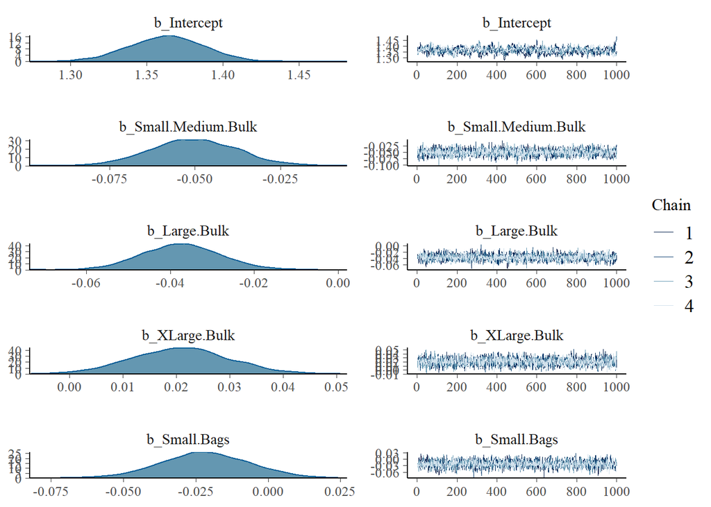

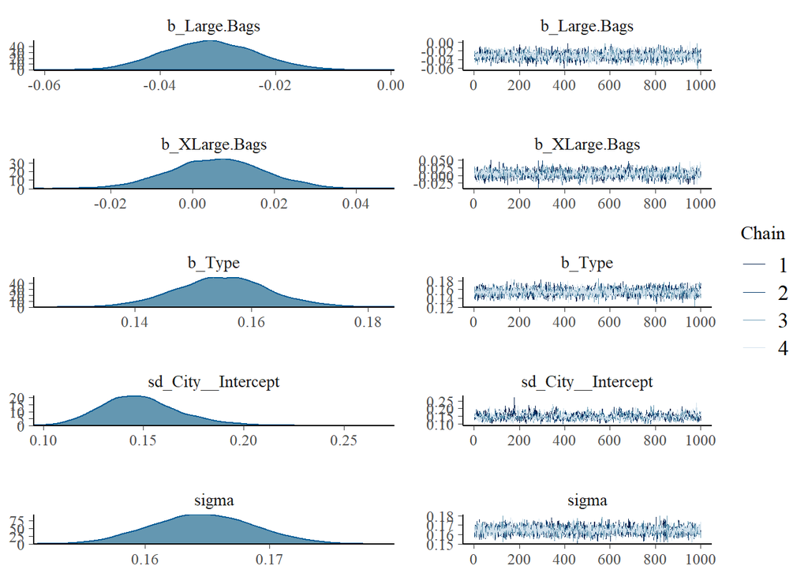

```r
plot(model_2)
```

```r
model_2
```

```
 Family: gaussian
  Links: mu = identity; sigma = identity
Formula: Average.Price ~ 1 + Small.Medium.Bulk + Large.Bulk + XLarge.Bulk + Small.Bags + Large.Bags + Large.Bags + XLarge.Bags + Type + (1 | City)
   Data: s_avocado (Number of observations: 888)
  Draws: 4 chains, each with iter = 2000; warmup = 1000; thin = 1;
         total post-warmup draws = 4000

Group-Level Effects:
~City (Number of levels: 37)
              Estimate Est.Error l-95% CI u-95% CI Rhat Bulk_ESS Tail_ESS
sd(Intercept)     0.15      0.02     0.11     0.19 1.00      545     1220

Population-Level Effects:
                  Estimate Est.Error l-95% CI u-95% CI Rhat Bulk_ESS Tail_ESS
Intercept             1.36      0.02     1.31     1.41 1.02      444      867
Small.Medium.Bulk    -0.05      0.01    -0.07    -0.03 1.00     2602     3137
Large.Bulk           -0.04      0.01    -0.06    -0.02 1.00     2954     2761
XLarge.Bulk           0.02      0.01     0.00     0.04 1.00     2537     2907
Small.Bags           -0.02      0.02    -0.05     0.01 1.00     2363     2468
Large.Bags           -0.03      0.01    -0.05    -0.02 1.00     3051     2807
XLarge.Bags           0.01      0.01    -0.02     0.03 1.00     1866     2098
Type                  0.16      0.01     0.14     0.17 1.00     3096     3128

Family Specific Parameters:
      Estimate Est.Error l-95% CI u-95% CI Rhat Bulk_ESS Tail_ESS
sigma     0.16      0.00     0.16     0.17 1.00     3995     2874

Draws were sampled using sampling(NUTS). For each parameter, Bulk_ESS
and Tail_ESS are effective sample size measures, and Rhat is the potential
scale reduction factor on split chains (at convergence, Rhat = 1).
```

```r
# Model 3:Varying intercept and slopes
priors_model3 <- get_prior(Average.Price ~ 1 + . + (1 + Type || City) - City, data = s_avocado)

model_3 <- brm(Average.Price ~ 1 + . + (1 + Type || City) - City,
  data = s_avocado,
  family = gaussian(),
  seed = 123,
  prior = priors_model3
)
```

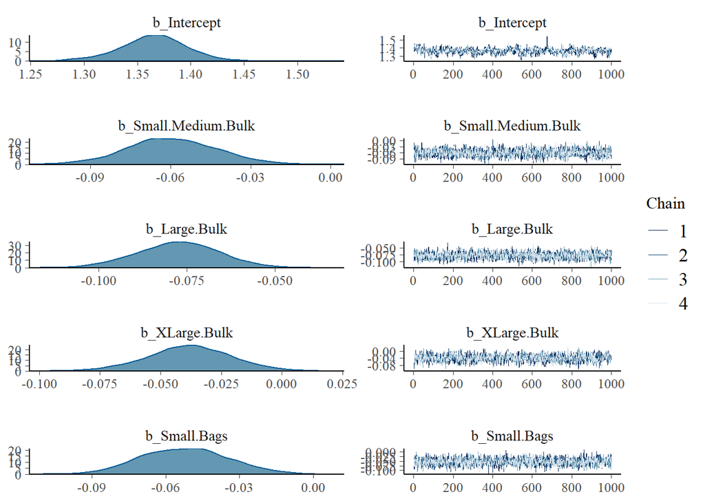

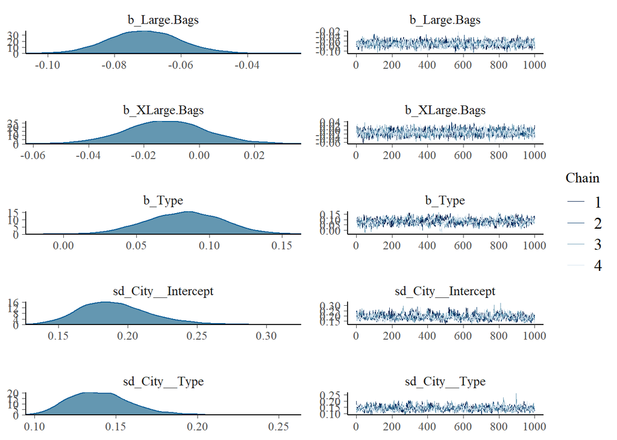

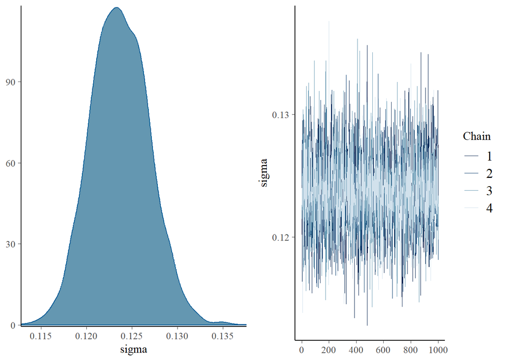

```r
plot(model_3)
```

```r
model_3
```

```
 Family: gaussian
  Links: mu = identity; sigma = identity
Formula: Average.Price ~ 1 + (Small.Medium.Bulk + Large.Bulk + XLarge.Bulk + Small.Bags + Large.Bags + XLarge.Bags + Type + City) + (1 + Type || City) - City
   Data: s_avocado (Number of observations: 888)
  Draws: 4 chains, each with iter = 2000; warmup = 1000; thin = 1;
         total post-warmup draws = 4000

Group-Level Effects:
~City (Number of levels: 37)
              Estimate Est.Error l-95% CI u-95% CI Rhat Bulk_ESS Tail_ESS
sd(Intercept)     0.19      0.03     0.15     0.25 1.01      518     1143
sd(Type)          0.14      0.02     0.11     0.18 1.00      717     1296

Population-Level Effects:
                  Estimate Est.Error l-95% CI u-95% CI Rhat Bulk_ESS Tail_ESS
Intercept             1.36      0.03     1.30     1.43 1.01      375      665
Small.Medium.Bulk    -0.06      0.02    -0.09    -0.03 1.00     1622     2017
Large.Bulk           -0.08      0.01    -0.10    -0.06 1.00     2451     3040
XLarge.Bulk          -0.04      0.02    -0.07    -0.00 1.00     1495     1985
Small.Bags           -0.05      0.02    -0.09    -0.02 1.00     1624     2620
Large.Bags           -0.07      0.01    -0.09    -0.05 1.00     1758     2392
XLarge.Bags          -0.01      0.01    -0.04     0.02 1.00     1951     2560
Type                  0.08      0.03     0.03     0.13 1.00      403      956

Family Specific Parameters:
      Estimate Est.Error l-95% CI u-95% CI Rhat Bulk_ESS Tail_ESS
sigma     0.12      0.00     0.12     0.13 1.00     4273     3025

Draws were sampled using sampling(NUTS). For each parameter, Bulk_ESS
and Tail_ESS are effective sample size measures, and Rhat is the potential
scale reduction factor on split chains (at convergence, Rhat = 1).
```

2. Explain each model and describe its structure (what they assume about potential population- level or group-level effects), and the type of priors used.

> Model 1: Complete pooling (fixed effect) Average.Price ~ Normal(alpha + Small.Medium.Bulk * beta + Large.Bulk * beta + XLarge.Bulk * beta + Small.Bags * beta + Large.Bags * beta + XLarge.Bags * beta + Type + beta)

The first model is a complete pooling model, which ignores that there are different cities so assumes that there is no variation between the clusters. The model assumes that all the variables are part of the same group and have the same slope/intercept. So, this is our most simple model: one parameter represents all the data.This model assumes that all parameters of the priors have distributed except the sigma which has an exponential distribution.

> Model 2: Varying intercept Average.Price ~ Normal(alpha + City[n] + Small.Medium.Bulk * beta + Large.Bulk * beta + XLarge.Bulk * beta + Small.Bags * beta + Large.Bags * beta + XLarge.Bags * beta + Type * beta)

This model assumes that each city has its own intercept (ui, i: indicating that each city is given a unique intercept), but the slope is the same for all cities, the intercept of the different cities has common prior distribution (normal distribution). This model also assumes that the outcome of the target variable average price is normally distributed around a mean with a some error. The sigma (overall variability) and the standard deviation (group level effect) have exponential distribution, which will allow only positive values.

## 4. Model checking (2.5pt)

1. Perform a prior sensitivity analysis for each model and modify or discard the model if appropriate. Justify.

```r
powerscale_sensitivity(model_1)
```

```
Sensitivity based on cjs_dist:
# A tibble: 9 × 4
  variable               prior likelihood diagnosis
  <chr>                  <dbl>      <dbl> <chr>
1 b_Intercept         0.000144     0.0796 -
2 b_Small.Medium.Bulk 0.000136     0.0772 -
3 b_Large.Bulk        0.000330     0.0842 -
4 b_XLarge.Bulk       0.000165     0.0838 -
5 b_Small.Bags        0.000118     0.0766 -
6 b_Large.Bags        0.000148     0.0804 -
7 b_XLarge.Bags       0.000207     0.0751 -
8 b_Type              0.000582     0.0850 -
9 sigma               0.00249      0.109  -
```

```r
powerscale_sensitivity(model_2)
```

```
Sensitivity based on cjs_dist:
# A tibble: 47 × 4
   variable               prior likelihood diagnosis
   <chr>                  <dbl>      <dbl> <chr>
 1 b_Intercept         0.00133      0.0358 -
 2 b_Small.Medium.Bulk 0.000359     0.0853 -
 3 b_Large.Bulk        0.00163      0.194  -
 4 b_XLarge.Bulk       0.000564     0.0953 -
 5 b_Small.Bags        0.000293     0.108  -
 6 b_Large.Bags        0.000366     0.0887 -
 7 b_XLarge.Bags       0.000547     0.0911 -
 8 b_Type              0.000574     0.126  -
 9 sd_City__Intercept  0.0126       0.0817 -
10 sigma               0.00186      0.228  -
# … with 37 more rows
```

```r
powerscale_sensitivity(model_3)
```

```
Sensitivity based on cjs_dist:
# A tibble: 85 × 4
   variable                prior likelihood diagnosis
   <chr>                   <dbl>      <dbl> <chr>
 1 b_Intercept         0.0000590     0.0407 -
 2 b_Small.Medium.Bulk 0.0000118     0.0985 -
 3 b_Large.Bulk        0.0000429     0.266  -
 4 b_XLarge.Bulk       0.0000532     0.279  -
 5 b_Small.Bags        0.0000452     0.346  -
 6 b_Large.Bags        0.0000161     0.176  -
 7 b_XLarge.Bags       0.0000141     0.0675 -
 8 b_Type              0.0000335     0.184  -
 9 sd_City__Intercept  0.000243      0.219  -
10 sd_City__Type       0.000146      0.204  -
# … with 75 more rows
```

> All models are not modified because the power-scaling sensitivity analysis that was conducted shows no prior-data conflict, which means that the function could not detect sensitivity to power scaling.
2. Conduct posterior predictive checks for each model to assess how well they fit the data. Explain what you conclude.

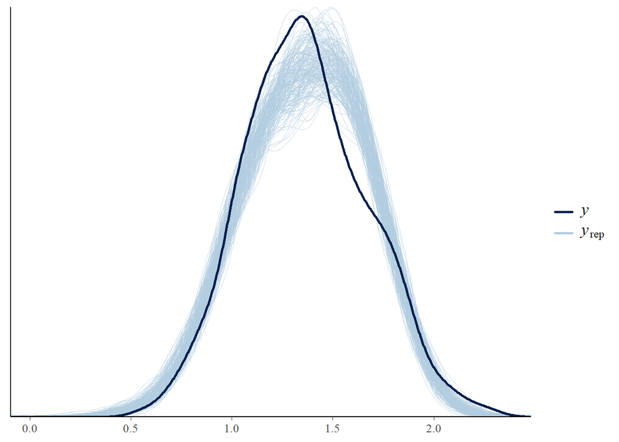

```r
# Model 1:
pp_check(model_1, ndraws = 200)
```

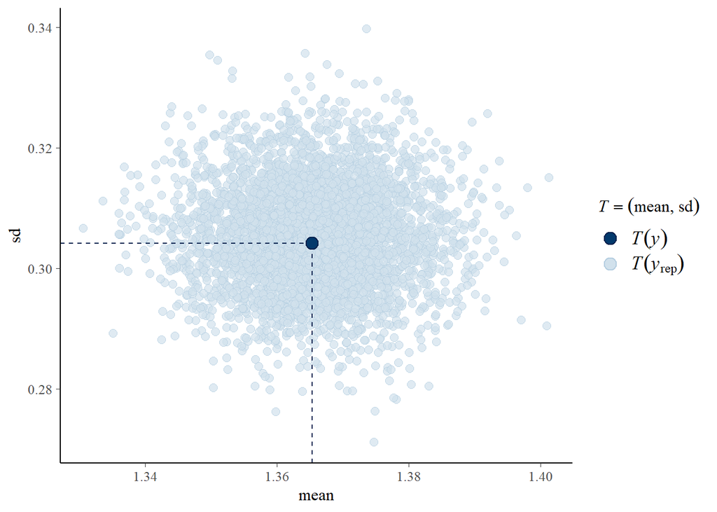

```r
pp_check(model_1, type = "stat_2d")
```

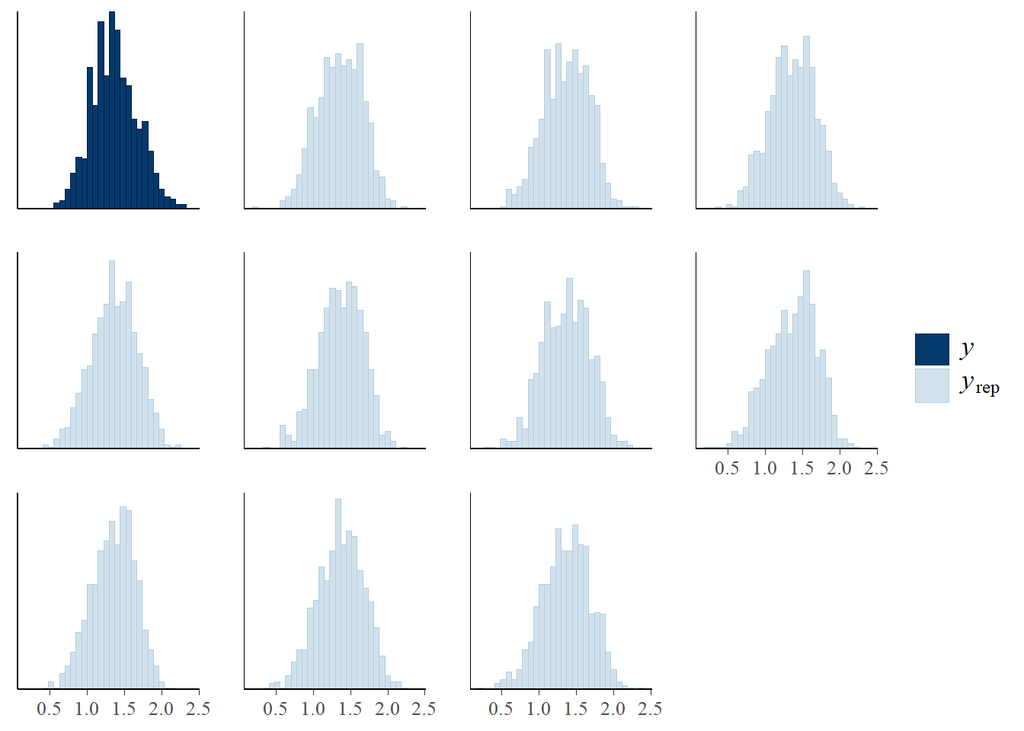

```r
pp_check(model_1, type = "hist")
```

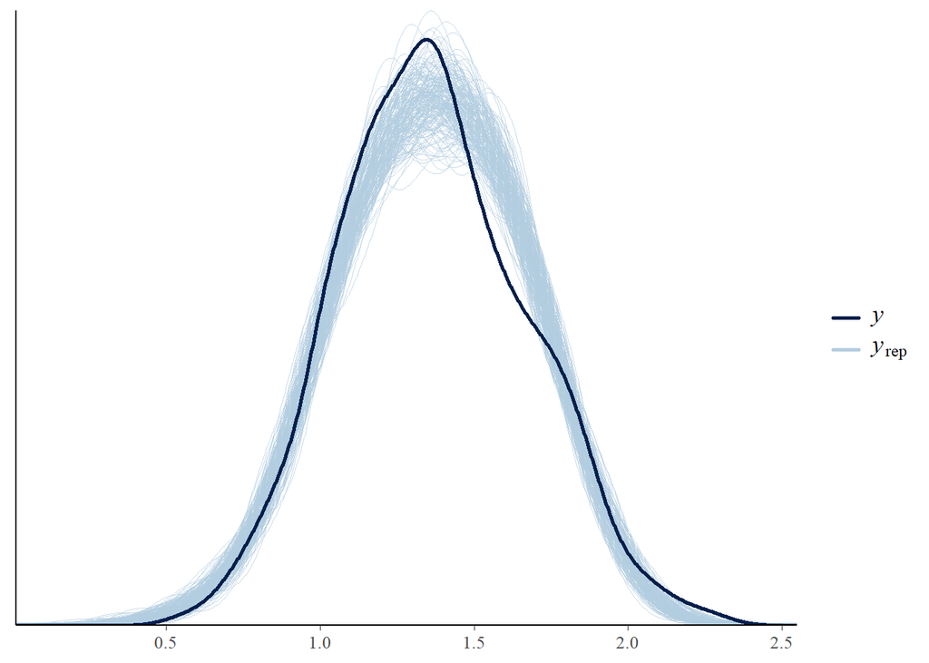

```r
# Model 2:
pp_check(model_2, ndraws = 200)
```

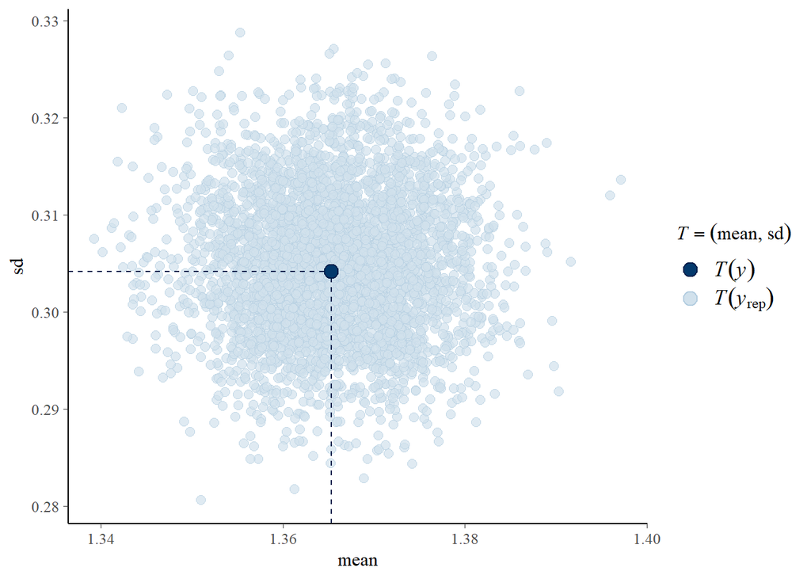

```r
pp_check(model_2, type = "stat_2d")
```

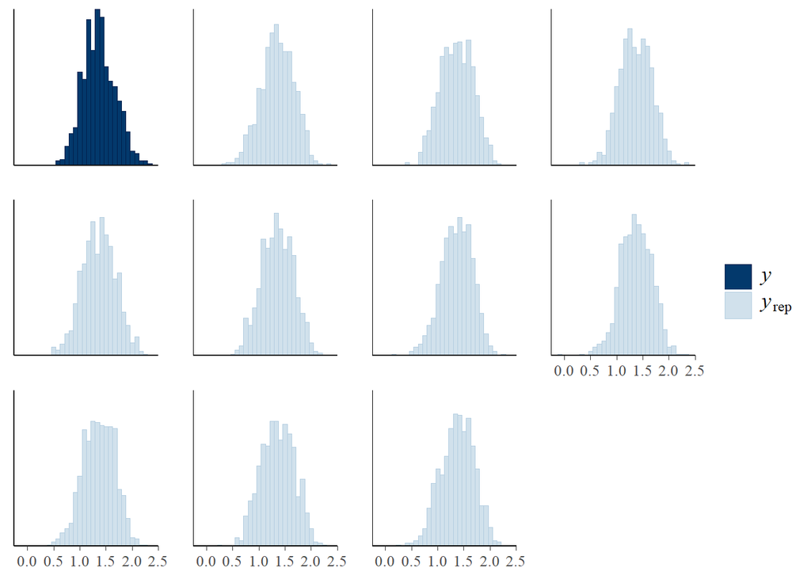

```r
pp_check(model_2, type = "hist")
```

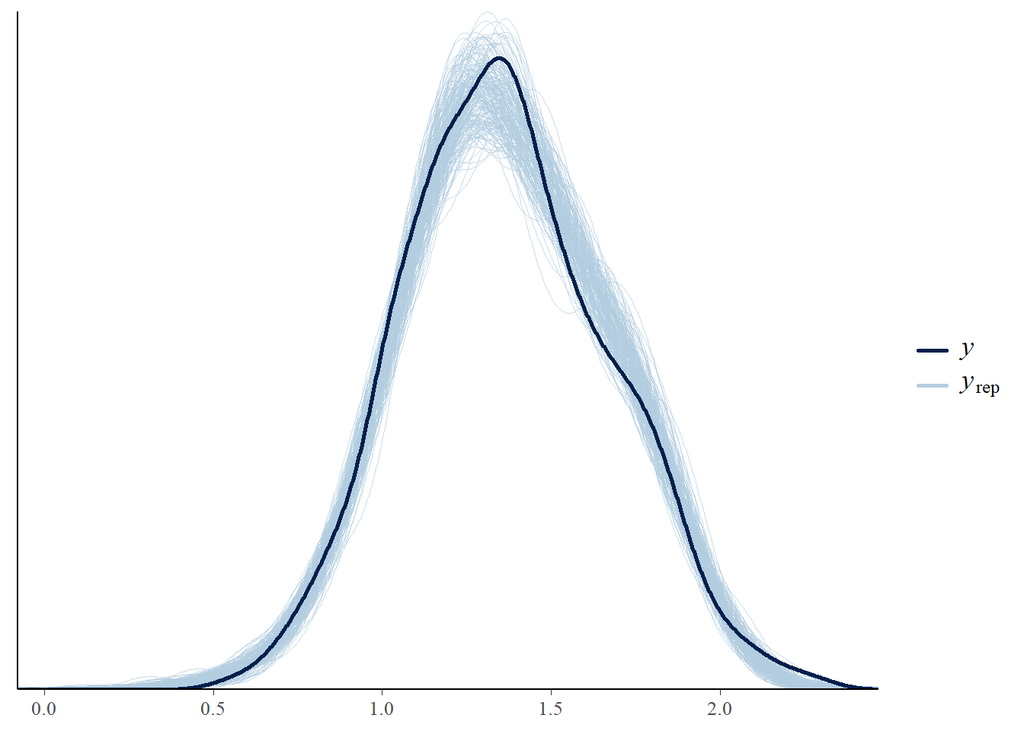

```r
# Model 3:
pp_check(model_3, ndraws = 200)
```

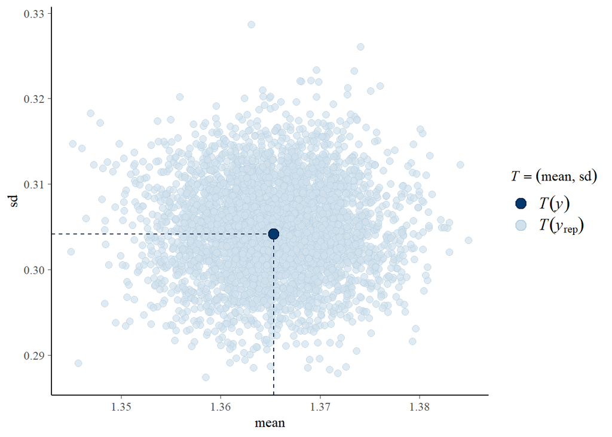

```r
pp_check(model_3, type = "stat_2d")
```

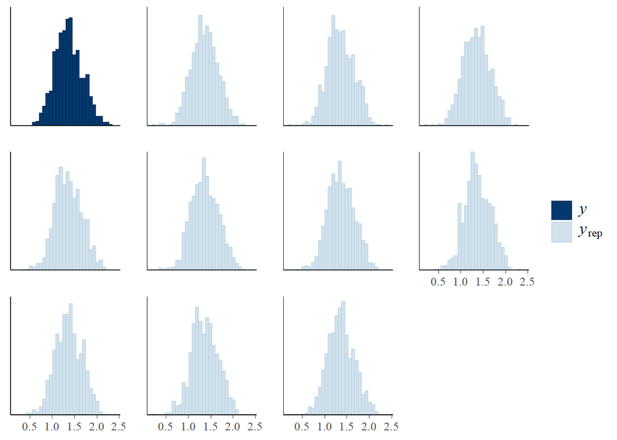

```r
pp_check(model_3, type = "hist")
```

> Model 2: The posterior predictive checks of model 2 shows that this model is adequate to describe data/is fitting the data well because the shape (both the histogram and density plot) of the simulated samples look similar to the observed data. The statistics of the simulated samples also look similar to what was observed.

## 5. Model Comparison (1.5pt)

1. Use loo or k-fold cross-validation to compare the models.

```r
m1 <- loo(model_1, cores = 1, reloo = TRUE)
m2 <- loo(model_2, cores = 1, reloo = TRUE)
m3 <- loo(model_3, cores = 1, reloo = TRUE)
loo_compare(m1, m2, m3)
```

```
        elpd_diff se_diff
model_3    0.0       0.0
model_2 -226.5      26.4
model_1 -419.4      33.8
```

2. Determine the best model based on predictive accuracy and justify your decision.

> The model with the highest predictive accuracy is model 3 (the model with varying intercept and slopes),following the second and lastly the first.It can be said that this model is reliable because the elpd difference is larger than 4, the standard deviation is larger than 2 and the number of observations are larger than 100.

## 6. Interpretation of Important Parameters (1.5pt)

Choose one of the best models and interpret its most important parameters in the context of the research question.

```r
posterior_summary(model_3)
```

```
                                           Estimate   Est.Error          Q2.5
b_Intercept                            1.364971e+00 0.031146811   1.298375620
b_Small.Medium.Bulk                   -5.947329e-02 0.016788184  -0.092235762
b_Large.Bulk                          -7.749097e-02 0.011518439  -0.100452966
b_XLarge.Bulk                         -3.815184e-02 0.017211290  -0.072440054
b_Small.Bags                          -5.228599e-02 0.017845643  -0.086015045
b_Large.Bags                          -7.094442e-02 0.010642668  -0.091345655
b_XLarge.Bags                         -1.194565e-02 0.014575006  -0.040588315
b_Type                                 8.300056e-02 0.026128728   0.031080166
sd_City__Intercept                     1.908598e-01 0.025497339   0.147227018
sd_City__Type                          1.404308e-01 0.018858665   0.108927496
sigma                                  1.236825e-01 0.003205596   0.117753971
r_City[Albany,Intercept]              -3.906809e-02 0.040983415  -0.118520733
r_City[Atlanta,Intercept]             -5.929971e-02 0.040781207  -0.137859202
r_City[BaltimoreWashington,Intercept]  5.540914e-02 0.042236116  -0.026459469
r_City[Boise,Intercept]                2.268834e-02 0.040418618  -0.056680661
r_City[Boston,Intercept]               2.165896e-01 0.041594462   0.137497175
r_City[BuffaloRochester,Intercept]    -2.173668e-01 0.040702197  -0.296716960
r_City[Charlotte,Intercept]            3.600574e-02 0.039765894  -0.041175267
r_City[Chicago,Intercept]              3.511842e-01 0.067656397   0.220904412
r_City[CincinnatiDayton,Intercept]    -1.528723e-01 0.039734364  -0.230479953
r_City[Columbus,Intercept]            -2.711365e-01 0.040949108  -0.347290949
r_City[DallasFtWorth,Intercept]       -1.093055e-01 0.045474575  -0.200639381
r_City[Denver,Intercept]               1.175968e-01 0.048727896   0.024695123
r_City[Detroit,Intercept]             -1.839945e-01 0.040975589  -0.264065898
r_City[GrandRapids,Intercept]         -7.560696e-02 0.043846226  -0.163334207
r_City[HarrisburgScranton,Intercept]  -1.050802e-01 0.040549847  -0.182043731
r_City[HartfordSpringfield,Intercept]  2.415089e-01 0.040197272   0.163416465
r_City[Houston,Intercept]             -1.485781e-01 0.046717474  -0.239483482
r_City[Indianapolis,Intercept]        -2.734286e-01 0.039886707  -0.350252308
r_City[Jacksonville,Intercept]         9.909177e-03 0.040126841  -0.069121852
                                              Q97.5
b_Intercept                            1.425086e+00
b_Small.Medium.Bulk                   -2.565551e-02
b_Large.Bulk                          -5.527860e-02
b_XLarge.Bulk                         -4.445489e-03
b_Small.Bags                          -1.704845e-02
b_Large.Bags                          -4.973237e-02
b_XLarge.Bags                          1.725083e-02
b_Type                                 1.334341e-01
```

[output cut: 8 more lines]

```
r_City[BuffaloRochester,Intercept]    -1.363191e-01
r_City[Charlotte,Intercept]            1.156268e-01
r_City[Chicago,Intercept]              4.866641e-01
r_City[CincinnatiDayton,Intercept]    -7.495440e-02
r_City[Columbus,Intercept]            -1.877647e-01
r_City[DallasFtWorth,Intercept]       -2.065912e-02
r_City[Denver,Intercept]               2.143645e-01
r_City[Detroit,Intercept]             -1.009491e-01
r_City[GrandRapids,Intercept]          9.095753e-03
r_City[HarrisburgScranton,Intercept]  -2.597888e-02
r_City[HartfordSpringfield,Intercept]  3.225834e-01
r_City[Houston,Intercept]             -5.492755e-02
r_City[Indianapolis,Intercept]        -1.947593e-01
r_City[Jacksonville,Intercept]         9.167112e-02
 [ reached getOption("max.print") -- omitted 57 rows ]
```

# Contributions of each member

- Yasemin: Preprocessing, Chapter 1. Dataset Selection, Choosing models, Chapter 3. Model Exploration Model 1, Chapter 4. Model Checking Model 1, Chapter 5. Model Comparison & Chapter 6.
- Wafa: Preprocessing, Chapter 1. Dataset Selection, Choosing models, Chapter 3. Model Exploration Model 2, Chapter 4. Model Checking Model 2, Chapter 5. Model Comparison & Chapter 6.
- Mladen: Found data, Preprocessing, Chapter 2. Research Question, Chapter 3. Model Exploration Model 3, Chapter 4. Model Checking Model 3, Chapter 5. Model Comparison & Chapter 6.

# References

[1] https://www.kaggle.com/datasets/neuromusic/avocado-prices

[2] https://www.statista.com/topics/3108/avocado-industry/#topicOverview